# Severe weather events and their effect on health and the economy

## Purpose:

To provide an overview and analysis of the effects that extreme weather events have on the health of the population and on the potential damage to property or crops. This information can be helpful when prioritizing resources to prepare for imminent inclement weather.

## Synopsis:

The U.S. National Oceanic and Atmospheric Administration (NOAA) maintains a storm database that tracks characteristics of major weather events in the United States. Some of the metrics observed include estimations of injuries, fatalities, and damage to property and crops. We will be looking at these metrics in detail to determine which types of events most negatively impact human health and which types of events most negatively impact the economy.

## Applications and Languages Used:

This was written using RStudio in mostly base R, with the help of the dpylr, tidyr, and ggplot2 packages. Knitted to HTML using the internal knitr capabilities and published to RPubs.

## Data Processing:

First, we set our working directory to receive the file.

```r
path <- "/home/benschnable/R/ReproducibleFinal"
if (!dir.exists(path)) { dir.create(path) }
setwd(path)
```

Then, download the file from the internet and load the data into R.

```r
url <- "https://d396qusza40orc.cloudfront.net/repdata%2Fdata%2FStormData.csv.bz2"
if (!file.exists(paste0(path, "/stormdata.csv.bz2"))) {
download.file(url, destfile = "stormdata.csv.bz2") }
stormdata <- read.csv("stormdata.csv.bz2")
```

We will need the following libraries for our analysis and subsequent plotting.

```r
library(dplyr)
library(tidyr)
library(ggplot2)
```

To first address the affect of extreme weather on human health, we will subset the initial dataframe to take only those rows that contain non-zero numbers of fatalities or injuries. Then we will add a column that sums the amount of fatalities and injuries per event so we can see the overall impact that each even has on human health.

```r
health <- filter(stormdata, FATALITIES > 0 | INJURIES > 0)
health <- select(health, c(STATE, EVTYPE, FATALITIES, INJURIES))
for ( i in seq_along(health[ ,1]) ) {
        health$HARM[i] <- sum(health$FATALITIES[i] + health$INJURIES[i])
}
dim(health)
```

```
## [1] 21929     5
```

Here we see the dimensions of our new dataframe. When we look at the summary statistics of event types (the EVTYPE variable), we see that there are several event types that are duplicated, but formatted differently, and that the top 20 types seem to have the most representation in the population. By creating a character vector of these top 20 events, we can further subset the data.

```r
summary(health$EVTYPE)
```

```
##                    TORNADO                  LIGHTNING
##                       7928                       3305
##                  TSTM WIND                FLASH FLOOD
##                       2930                        931
##          THUNDERSTORM WIND             EXCESSIVE HEAT
##                        682                        678
##                  HIGH WIND                      FLOOD
##                        525                        410
##                RIP CURRENT         THUNDERSTORM WINDS
##                        399                        359
##                       HAIL                  AVALANCHE
##                        288                        239
##               RIP CURRENTS               WINTER STORM
##                        238                        227
##                STRONG WIND                       HEAT
##                        217                        209
##                   WILDFIRE                 HEAVY SNOW
##                        196                        189
##           WILD/FOREST FIRE                 HEAVY RAIN
##                        135                        121
##               EXTREME COLD                 HIGH WINDS
##                        115                         98
##                  ICE STORM                        FOG
##                         95                         92
##    EXTREME COLD/WIND CHILL                  HIGH SURF
##                         91                         87
##                   BLIZZARD            COLD/WIND CHILL
##                         86                         75
##             WINTER WEATHER                 DUST STORM
##                         49                         45
##       URBAN/SML STREAM FLD             TROPICAL STORM
##                         43                         42
##       HEAVY SURF/HIGH SURF                       WIND
##                         39                         39
##                  DENSE FOG                       COLD
##                         34                         31
##                  HURRICANE                  HEAT WAVE
##                         31                         30
##             TSTM WIND/HAIL          HURRICANE/TYPHOON
##                         28                         26
```

[output cut: 45 more lines]

```
##                          2                          2
##           FALLING SNOW/ICE       FLASH FLOODING/FLOOD
##                          2                          2
##               FLASH FLOODS               FUNNEL CLOUD
##                          2                          2
##                 GUSTY WIND                 HEAVY SEAS
##                          2                          2
##                 HIGH WATER            HIGH WINDS/COLD
##                          2                          2
##             HURRICANE OPAL HURRICANE-GENERATED SWELLS
##                          2                          2
##              MARINE MISHAP                   Mudslide
##                          2                          2
##                  RAIN/SNOW                    (Other)
##                          2                        133
```

```r
topconditions <- c("tornado", "lightning", "tstm wind", "flash flood",
                   "thunderstorm wind", "excessive heat", "high wind",
                   "flood", "rip current", "thunderstorm winds", "hail",
                   "avalanche", "rip currents", "winter storm", "strong wind",
                   "heat", "wildfire", "heavy snow", "wild/forest fire", "heavy rain")
health$EVTYPE <- tolower(health$EVTYPE)
health <- filter(health, EVTYPE %in% topconditions)
dim(health)
```

```
## [1] 20206     5
```

Our new dataset has 20206 of the original 21929 observations, so it is safe to say that this is a good representative sample of the data. Next we will split this dataset by the EVTYPE variable so that we can combine observations that belong together (i.e. “tstm wind” and “thunderstorm winds” etc.)

```r
tmp <- split(health, health$EVTYPE)
h <- rbind(tmp[[2]], tmp[[6]])
h$EVTYPE <- "excessive heat"
f <- rbind(tmp[[3]], tmp[[4]])
f$EVTYPE <- "flooding"
t <- rbind(tmp[[9]], tmp[[13]], tmp[[14]], tmp[[15]], tmp[[17]])
t$EVTYPE <- "thunderstorm winds"
c <- rbind(tmp[[11]], tmp[[12]])
c$EVTYPE <- "rip currents"
w <- rbind(tmp[[18]], tmp[[19]])
w$EVTYPE <- "wildfire"
finaldf <- rbind(tmp[[1]], tmp[[5]], tmp[[7]], tmp[[8]], tmp[[10]], tmp[[16]],
                 tmp[[20]], h, f, t, c, w)
```

Finally, we will group this dataset by event type and look at some summary statistics that we can use to visualize what is going on.

```r
plotdata <- finaldf %>%
        group_by(EVTYPE) %>%
        summarize(count = n(),
                  sum = sum(HARM),
                  mean = mean(HARM))
plotdata
```

```
## # A tibble: 12 x 4
##    EVTYPE             count   sum  mean
##    <chr>              <int> <dbl> <dbl>
##  1 avalanche            239   394  1.65
##  2 excessive heat       887 11465 12.9
##  3 flooding            1341 10014  7.47
##  4 hail                 288  1376  4.78
##  5 heavy rain           121   349  2.88
##  6 heavy snow           189  1148  6.07
##  7 lightning           3305  6046  1.83
##  8 rip currents         637  1101  1.73
##  9 thunderstorm winds  4713 11822  2.51
## 10 tornado             7928 96979 12.2
## 11 wildfire             331  1543  4.66
## 12 winter storm         227  1527  6.73
```

Next we will take a similar approach to looking at the data that pertains strictly to the economic impact of extreme weather events - damage to property and damage to crops.

```r
economic <- filter(stormdata, PROPDMG > 0 | CROPDMG > 0)
economic <- select(economic, c(STATE, EVTYPE, PROPDMG, PROPDMGEXP,
                               CROPDMG, CROPDMGEXP))
dim(economic)
```

```
## [1] 245031      6
```

```r
summary(economic$EVTYPE)
```

```
##                TSTM WIND        THUNDERSTORM WIND                  TORNADO
##                    61475                    43465                    39361
##                     HAIL              FLASH FLOOD       THUNDERSTORM WINDS
##                    25969                    20659                    12005
##                LIGHTNING                    FLOOD                HIGH WIND
##                    10360                    10058                     5352
##              STRONG WIND             WINTER STORM               HEAVY SNOW
##                     3279                     1389                     1244
##               HEAVY RAIN                 WILDFIRE     URBAN/SML STREAM FLD
##                     1032                      778                      675
##                ICE STORM               HIGH WINDS           TSTM WIND/HAIL
##                      667                      611                      429
##           TROPICAL STORM           WINTER WEATHER         WILD/FOREST FIRE
##                      407                      374                      323
##           FLASH FLOODING        FLOOD/FLASH FLOOD                  DROUGHT
##                      294                      277                      266
##                 BLIZZARD         LAKE-EFFECT SNOW                LANDSLIDE
##                      213                      194                      189
##              STORM SURGE            COASTAL FLOOD              URBAN FLOOD
##                      173                      161                      139
##                HURRICANE       WINTER WEATHER/MIX               LIGHT SNOW
##                      123                      122                      119
##             FROST/FREEZE              RIVER FLOOD         MARINE TSTM WIND
##                      116                      106                      104
##             EXTREME COLD               DUST DEVIL           URBAN FLOODING
##                       99                       81                       80
##               DUST STORM        HURRICANE/TYPHOON           DRY MICROBURST
##                       78                       70                       69
##                DENSE FOG                      FOG                 FLOODING
##                       66                       65                       56
##                HIGH SURF         COASTAL FLOODING                     WIND
##                       56                       55                       55
##                AVALANCHE                     SNOW         STORM SURGE/TIDE
##                       54                       48                       47
##               WATERSPOUT  THUNDERSTORM WINDS HAIL             STRONG WINDS
##                       45                       40                       37
##          TSTM WIND (G45)      TROPICAL DEPRESSION       MARINE STRONG WIND
##                       36                       35                       34
##            FREEZING RAIN      THUNDERSTORM WINDSS                    OTHER
##                       33                       33                       32
```

[output cut: 13 more lines]

```
##                       16                       16                       15
##      MIXED PRECIPITATION                     HEAT              SNOW SQUALL
##                       15                       14                       14
##                  TSUNAMI               GUSTY WIND             FLASH FLOODS
##                       14                       13                       12
##             FUNNEL CLOUD                HEAT WAVE           RIVER FLOODING
##                       12                       12                       12
##              Gusty Winds               SMALL HAIL       SNOW FREEZING RAIN
##                       10                       10                       10
##             SNOW SQUALLS   DROUGHT/EXCESSIVE HEAT     HEAVY RAINS/FLOODING
##                       10                        9                        9
##                   SEICHE          TSTM WIND (G40)                  TYPHOON
##                        9                        9                        9
##                  (Other)
##                      609
```

As before, we will take the top events (this time there are 23 at the top that seem to need further processing/combining).

```r
topconditions2 <- c("tstm wind", "thunderstorm wind", "tornado", "hail",
                    "flash flood", "thunderstorm winds", "lightning", "flood",
                    "high wind", "strong wind", "winter storm", "heavy snow",
                    "heavy rain", "wildfire", "urban/sml stream fld", "ice storm",
                    "high winds", "tstm wind/hail", "tropical storm",
                    "winter weather", "wild/forest fire", "flash flooding",
                    "flood/flash flood")
economic$EVTYPE <- tolower(economic$EVTYPE)
economic <- filter(economic, EVTYPE %in% topconditions2)
dim(economic)
```

```
## [1] 240486      6
```

And again, our subset shows 240486/245031 initial observations, making this a good representative sample. As before, we will split this dataframe by the EVTYPE variable and reconstruct it by combining like elements.

```r
tmp2 <- split(economic, economic$EVTYPE)
f <- rbind(tmp2[[1]], tmp2[[2]], tmp2[[3]], tmp2[[4]], tmp2[[19]])
f$EVTYPE <- "flooding"
h <- rbind(tmp2[[5]], tmp2[[18]])
h$EVTYPE <- "hail"
w <- rbind(tmp2[[8]], tmp2[[9]], tmp2[[12]], tmp2[[13]], tmp2[[14]], tmp2[[17]])
w$EVTYPE <- "wind damage"
r <- rbind(tmp2[[20]], tmp2[[21]])
r$EVTYPE <- "wildfire"
e <- rbind(tmp2[[22]], tmp2[[23]])
e$EVTYPE <- "winter storm"

econdf <- rbind(tmp2[[6]], tmp2[[7]], tmp2[[10]], tmp2[[11]], tmp2[[15]], tmp2[[16]],
                f, h, w, r, e)
```

An additional challenge here is to find the true costs of the property and crop damage. The table shows two columns relating to each variable - the cost coefficient (PROPDMG/CROPDMG), and the exponent to which each is raised (PROPDMGEXP/CROPDMGEXP). To do this, we convert the exponent strings to lowercase and see which unique values exists in the dataset. This lets us know how to prepare our for loop with if/else conditions to create each element of the new total cost column. This process for both the property damage and the crop damage is the most expensive (i.e. calculation heavy) part of the whole analysis.

```r
econdf$PROPDMGEXP <- tolower(econdf$PROPDMGEXP)
econdf$CROPDMGEXP <- tolower(econdf$CROPDMGEXP)

unique(econdf$PROPDMGEXP)
```

```
##  [1] "k" "m" ""  "5" "0" "+" "b" "4" "7" "h" "-" "2" "6" "3"
```

```r
unique(econdf$CROPDMGEXP)
```

```
## [1] ""  "m" "k" "b" "0" "?"
```

```r
for ( i in seq_along(econdf[ ,1]) ) {
        if ( econdf$PROPDMGEXP[i] == "k") {
                econdf$TOTALPROP[i] <- (econdf$PROPDMG[i] * 1000)
        }
        else if ( econdf$PROPDMGEXP[i] == "m") {
                econdf$TOTALPROP[i] <- (econdf$PROPDMG[i] * 1000000)
        }
        else if ( econdf$PROPDMGEXP[i] == "h") {
                econdf$TOTALPROP[i] <- (econdf$PROPDMG[i] * 100)
        }
        else if ( econdf$PROPDMGEXP[i] == "b") {
                econdf$TOTALPROP[i] <- (econdf$PROPDMG[i] * 1000000000)
        }
        else if ( econdf$PROPDMGEXP[i] %in% c("", "+", "-", "?")) {
                econdf$TOTALPROP[i] <- econdf$PROPDMG[i]
        }
        else { econdf$TOTALPROP[i] <- (econdf$PROPDMG[i] *
                                               10^(as.numeric(econdf$PROPDMGEXP[i])))
        }
}
```

```r
for ( i in seq_along(econdf[ ,1]) ) {
        if ( econdf$CROPDMG[i] > 0 ) {
                if ( econdf$CROPDMGEXP[i] == "k") {
                econdf$TOTALCROP[i] <- (econdf$CROPDMG[i] * 1000)
                }
                else if ( econdf$CROPDMGEXP[i] == "m") {
                econdf$TOTALCROP[i] <- (econdf$CROPDMG[i] * 1000000)
                }
                else if ( econdf$CROPDMGEXP[i] == "h") {
                econdf$TOTALCROP[i] <- (econdf$CROPDMG[i] * 100)
                }
                else if ( econdf$CROPDMGEXP[i] == "b") {
                econdf$TOTALCROP[i] <- (econdf$CROPDMG[i] * 1000000000)
                }
                else if ( econdf$CROPDMGEXP[i] %in% c("", "+", "-", "?")) {
                econdf$TOTALCROP[i] <- econdf$CROPDMG[i]
                }
                else { econdf$TOTALCROP[i] <- (econdf$CROPDMG[i] *
                                                       10^(as.numeric(econdf$CROPDMGEXP[i])))
                }
        }
        else { econdf$TOTALCROP[i] <- 0 }
}
```

Since we will be looking at two variables in our economic dataset (TOTALPROP and TOTALCROP), we will have to do one last transform to make this a long and tidy dataframe, ready to be plotted.

```r
econplot <- select(econdf, c(EVTYPE, TOTALPROP, TOTALCROP)) %>%
        gather(event, total, TOTALCROP:TOTALPROP) %>%
        group_by(EVTYPE, event) %>%
        summarize(sum = sum(total))
econplot
```

```
## # A tibble: 22 x 3
## # Groups:   EVTYPE [11]
##    EVTYPE     event               sum
##    <chr>      <chr>             <dbl>
##  1 flooding   TOTALCROP   7201923700
##  2 flooding   TOTALPROP 162020518046.
##  3 hail       TOTALCROP   3090650723
##  4 hail       TOTALPROP  15779603013.
##  5 heavy rain TOTALCROP    733399800
##  6 heavy rain TOTALPROP    694248090
##  7 heavy snow TOTALCROP    134653100
##  8 heavy snow TOTALPROP    932759140
##  9 ice storm  TOTALCROP   5022113500
## 10 ice storm  TOTALPROP   3944927860
## # … with 12 more rows
```

We will be looking at paired bar charts, so sorting the results and taking the top 6 would be prudent, as to avoid overcrowding the visualization.

```r
econplot %>% arrange(desc(sum)) %>% filter(event == "TOTALPROP")
```

```
## # A tibble: 11 x 3
## # Groups:   EVTYPE [11]
##    EVTYPE         event               sum
##    <chr>          <chr>             <dbl>
##  1 flooding       TOTALPROP 162020518046.
##  2 tornado        TOTALPROP  56947380676.
##  3 wind damage    TOTALPROP  15966301319.
##  4 hail           TOTALPROP  15779603013.
##  5 wildfire       TOTALPROP   7766943500
##  6 tropical storm TOTALPROP   7703890550
##  7 winter storm   TOTALPROP   6709363251
##  8 ice storm      TOTALPROP   3944927860
##  9 heavy snow     TOTALPROP    932759140
## 10 lightning      TOTALPROP    930379430.
## 11 heavy rain     TOTALPROP    694248090
```

```r
econplot %>% arrange(desc(sum)) %>% filter(event == "TOTALCROP")
```

```
## # A tibble: 11 x 3
## # Groups:   EVTYPE [11]
##    EVTYPE         event            sum
##    <chr>          <chr>          <dbl>
##  1 flooding       TOTALCROP 7201923700
##  2 ice storm      TOTALCROP 5022113500
##  3 hail           TOTALCROP 3090650723
##  4 wind damage    TOTALCROP 1903750588
##  5 heavy rain     TOTALCROP  733399800
##  6 tropical storm TOTALCROP  678346000
##  7 tornado        TOTALCROP  414953270
##  8 wildfire       TOTALCROP  402269630
##  9 heavy snow     TOTALCROP  134653100
## 10 winter storm   TOTALCROP   41944000
## 11 lightning      TOTALCROP   12092090
```

```r
lab <- c("flooding", "tornado", "hail", "wind damage", "ice storm", "tropical storm")
```

There is some overlap in the top 6 of each category, so we choose those events to examine in our visualization.

## Results:

Looking at the dataset that pertains to effects on human health, we can see that there are a disproportionate amount of data concerning tornadoes. Therefore, showing the average number of injuries or fatalities per extreme weather event seemed the more prudent decision.

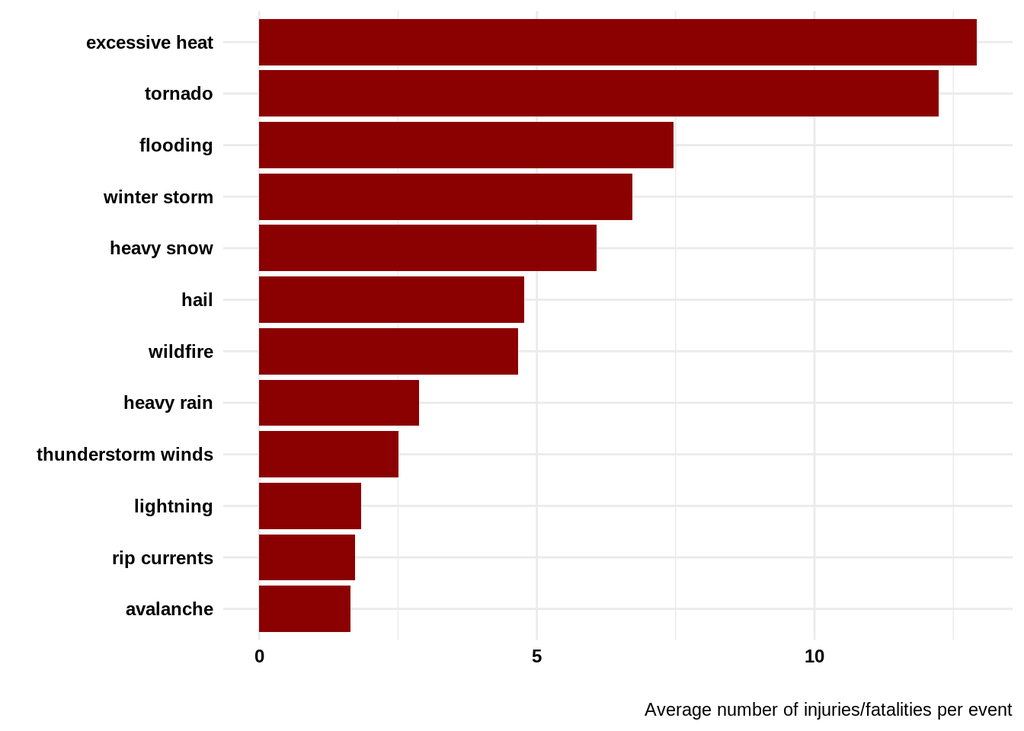

```r
g <- ggplot(plotdata, aes(x = mean, y = reorder(EVTYPE, mean)))
g + geom_col(fill = "darkred") + labs(y = "", x = "",
                caption = "Average number of injuries/fatalities per event") +
        theme_minimal() + theme(axis.text = element_text(color = "black",
                                                         size = 9, face = "bold"))
```

Now we see that, on average, the most fatalities and injuries are a result of incidents of excessive heat, closely followed by tornadoes.

Finally, we will look at the dataset showing the adverse economic effects of extreme weather incidents.

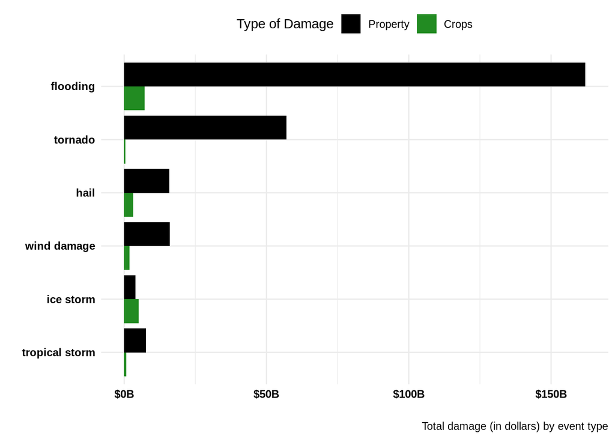

```r
xl <- c(0, 50, 100, 150) ## Label ticks determined by initial exploratory
                         ## plots of the data

econplot %>% filter(EVTYPE %in% lab) %>%
        ggplot(aes(x = sum, y = reorder(EVTYPE, sum), fill = event)) +
        geom_bar(stat = "identity", position = "dodge") +
        scale_fill_manual(values = c("forestgreen", "black"),
                          labels = c("Crops", "Property")) +
        scale_x_continuous(labels = paste0("$", xl, "B")) +
        labs(y = "", x = "", fill = "Type of Damage",
             caption = "Total damage (in dollars) by event type") +
        theme_minimal() + theme(legend.position = "top",
                                axis.text = element_text(color = "black",
                                                size = 9, face = "bold")) +
        guides(fill = guide_legend(reverse = TRUE))
```